# Predicting Loan Default Risk

# 1. The Business Problem

A small bank got about 500 loan applications and I am responsible for determining if customers are creditworthy to give a loan to. For this project, I will analyze the business problem using the classification model and provide a list of creditworthy customers to the manager of the bank.

I have the following information to work with:

1. Data on all past applications
2. The list of customers that need to be processed

## Key Decisions:

**1. What decisions needs to be made?**

The decisions to be made is which customers are creditworthy to give a loan to.

**2. What data is needed to inform those decisions?**

# 2. Data Preparation

```r
library(tidyverse)
library(corrplot)
library(ggplot2)
library(rpart)
library(rpart.plot)
library(caret)
library(AppliedPredictiveModeling)
library(readxl)
library(pROC)
library(randomForest)
```

After loading the required packages for analysis, we need to load the data sets to have a look on the data and check if data cleansing is needed.

```r
# Load data
data <- read_excel("credit-data-training.xlsx")

data2 <- read_excel(("customers-to-score.xlsx"))

# Check the first few rows
head(data)
```

| Credit-Application-Result | Account-Balance | Duration-of-Credit-Month | Payment-Status-of-Previous-Credit | Purpose | Credit-Amount | Value-Savings-Stocks | Length-of-current-employment | Instalment-per-cent | Guarantors | Duration-in-Current-address | Most-valuable-available-asset | Age-years | Concurrent-Credits | Type-of-apartment | No-of-Credits-at-this-Bank | Occupation | No-of-dependents | Telephone | Foreign-Worker |
| --- | --- | --- | --- | --- | --- | --- | --- | --- | --- | --- | --- | --- | --- | --- | --- | --- | --- | --- | --- |
| Creditworthy | Some Balance | 4 | Paid Up | Other | 1494 | £100-£1000 | < 1yr | 1 | None | 2 | 1 | NA | Other Banks/Depts | 2 | 1 | 1 | 2 | 1 | 2 |
| Creditworthy | Some Balance | 4 | Paid Up | Home Related | 1494 | £100-£1000 | < 1yr | 1 | None | 2 | 1 | 29 | Other Banks/Depts | 2 | 1 | 1 | 2 | 1 | 2 |
| Creditworthy | Some Balance | 4 | No Problems (in this bank) | Home Related | 1544 | None | 1-4 yrs | 2 | None | 1 | 1 | 42 | Other Banks/Depts | 2 | More than 1 | 1 | 2 | 1 | 1 |
| Creditworthy | Some Balance | 4 | No Problems (in this bank) | Home Related | 3380 | None | 1-4 yrs | 1 | None | 1 | 1 | 37 | Other Banks/Depts | 2 | 1 | 1 | 2 | 1 | 1 |
| Creditworthy | No Account | 6 | Paid Up | Home Related | 343 | None | < 1yr | 4 | None | 1 | 1 | 27 | Other Banks/Depts | 2 | 1 | 1 | 1 | 1 | 1 |
| Creditworthy | Some Balance | 6 | No Problems (in this bank) | Home Related | 362 | < £100 | < 1yr | 4 | None | NA | 3 | 52 | Other Banks/Depts | 2 | More than 1 | 1 | 1 | 1 | 1 |

```r
# Have a glimpse on the data
glimpse(data)
```

```
Rows: 500
Columns: 20
$ `Credit-Application-Result`         <chr> "Creditworthy", "Creditworthy", "Creditworth…
$ `Account-Balance`                   <chr> "Some Balance", "Some Balance", "Some Balanc…
$ `Duration-of-Credit-Month`          <dbl> 4, 4, 4, 4, 6, 6, 6, 6, 6, 6, 6, 6, 6, 6, 6,…
$ `Payment-Status-of-Previous-Credit` <chr> "Paid Up", "Paid Up", "No Problems (in this …
$ Purpose                             <chr> "Other", "Home Related", "Home Related", "Ho…
$ `Credit-Amount`                     <dbl> 1494, 1494, 1544, 3380, 343, 362, 433, 454, …
$ `Value-Savings-Stocks`              <chr> "£100-£1000", "£100-£1000", "None", "None", …
$ `Length-of-current-employment`      <chr> "< 1yr", "< 1yr", "1-4 yrs", "1-4 yrs", "< 1…
$ `Instalment-per-cent`               <dbl> 1, 1, 2, 1, 4, 4, 4, 3, 3, 2, 3, 4, 2, 1, 2,…
$ Guarantors                          <chr> "None", "None", "None", "None", "None", "Non…
$ `Duration-in-Current-address`       <dbl> 2, 2, 1, 1, 1, NA, NA, NA, 3, 4, 4, NA, 2, N…
$ `Most-valuable-available-asset`     <dbl> 1, 1, 1, 1, 1, 3, 2, 2, 1, 1, 1, 4, 1, 2, 2,…
$ `Age-years`                         <dbl> NA, 29, 42, 37, 27, 52, 24, 22, 28, 23, 39, …
$ `Concurrent-Credits`                <chr> "Other Banks/Depts", "Other Banks/Depts", "O…
$ `Type-of-apartment`                 <dbl> 2, 2, 2, 2, 2, 2, 1, 2, 2, 1, 2, 3, 2, 2, 2,…
$ `No-of-Credits-at-this-Bank`        <chr> "1", "1", "More than 1", "1", "1", "More tha…
$ Occupation                          <dbl> 1, 1, 1, 1, 1, 1, 1, 1, 1, 1, 1, 1, 1, 1, 1,…
$ `No-of-dependents`                  <dbl> 2, 2, 2, 2, 1, 1, 2, 1, 1, 1, 1, 1, 1, 1, 1,…
$ Telephone                           <dbl> 1, 1, 1, 1, 1, 1, 1, 1, 1, 1, 2, 1, 1, 1, 1,…
$ `Foreign-Worker`                    <dbl> 2, 2, 1, 1, 1, 1, 1, 1, 1, 1, 1, 1, 2, 1, 1,…
```

The past application data has 500 rows, 20 variables. `Credit-Application-Result` is the target variable.

For all variables, there are only two types of data: Character for categorical data and Double for numeric data.

Firstly, we need to replace the “-” in variable names by underscore "_" for better column indexing.

```r
names(data) <- gsub(x = names(data), pattern = "-", replacement = "_")
names(data2) <- gsub(x = names(data2), pattern = "-", replacement = "_")
```

```r
summary(data)
```

```
 Credit_Application_Result Account_Balance    Duration_of_Credit_Month
 Length:500                Length:500         Min.   : 4.00
 Class :character          Class :character   1st Qu.:12.00
 Mode  :character          Mode  :character   Median :18.00
                                              Mean   :21.43
                                              3rd Qu.:24.00
                                              Max.   :60.00

 Payment_Status_of_Previous_Credit   Purpose          Credit_Amount   Value_Savings_Stocks
 Length:500                        Length:500         Min.   :  276   Length:500
 Class :character                  Class :character   1st Qu.: 1357   Class :character
 Mode  :character                  Mode  :character   Median : 2236   Mode  :character
                                                      Mean   : 3200
                                                      3rd Qu.: 3942
                                                      Max.   :18424

 Length_of_current_employment Instalment_per_cent  Guarantors
 Length:500                   Min.   :1.00        Length:500
 Class :character             1st Qu.:2.00        Class :character
 Mode  :character             Median :3.00        Mode  :character
                              Mean   :3.01
                              3rd Qu.:4.00
                              Max.   :4.00

 Duration_in_Current_address Most_valuable_available_asset   Age_years
 Min.   :1.00                Min.   :1.00                  Min.   :19.00
 1st Qu.:2.00                1st Qu.:1.00                  1st Qu.:27.00
 Median :2.00                Median :3.00                  Median :33.00
 Mean   :2.66                Mean   :2.36                  Mean   :35.64
 3rd Qu.:4.00                3rd Qu.:3.00                  3rd Qu.:42.00
 Max.   :4.00                Max.   :4.00                  Max.   :75.00
 NA's   :344                                               NA's   :12
 Concurrent_Credits Type_of_apartment No_of_Credits_at_this_Bank   Occupation
 Length:500         Min.   :1.000     Length:500                 Min.   :1
 Class :character   1st Qu.:2.000     Class :character           1st Qu.:1
 Mode  :character   Median :2.000     Mode  :character           Median :1
                    Mean   :1.928                                Mean   :1
                    3rd Qu.:2.000                                3rd Qu.:1
                    Max.   :3.000                                Max.   :1

 No_of_dependents   Telephone   Foreign_Worker
 Min.   :1.000    Min.   :1.0   Min.   :1.000
 1st Qu.:1.000    1st Qu.:1.0   1st Qu.:1.000
 Median :1.000    Median :1.0   Median :1.000
 Mean   :1.146    Mean   :1.4   Mean   :1.038
 3rd Qu.:1.000    3rd Qu.:2.0   3rd Qu.:1.000
 Max.   :2.000    Max.   :2.0   Max.   :2.000
```

By previous `glimpse(past_data)`, we found that there were missing value. Let’s check the counts of missing values

```r
colSums(sapply(data, is.na))
```

```
        Credit_Application_Result                   Account_Balance
                                0                                 0
         Duration_of_Credit_Month Payment_Status_of_Previous_Credit
                                0                                 0
                          Purpose                     Credit_Amount
                                0                                 0
             Value_Savings_Stocks      Length_of_current_employment
                                0                                 0
              Instalment_per_cent                        Guarantors
                                0                                 0
      Duration_in_Current_address     Most_valuable_available_asset
                              344                                 0
                        Age_years                Concurrent_Credits
                               12                                 0
                Type_of_apartment        No_of_Credits_at_this_Bank
                                0                                 0
                       Occupation                  No_of_dependents
                                0                                 0
                        Telephone                    Foreign_Worker
                                0                                 0
```

```r
colSums(sapply(data2, is.na))
```

[output not shown]

For unlabeled rows (new_data), no missing values. But for 500 labeled rows (past_data), `Duration-in-Current-address` and `Age-years` have 344 and 12 missing values respectively. We have to remove the `Duration-in-Current-address` due to the high portion of missing values. For latter, we can fill in with median values of `Age-years`.

```r
# Remove `Duration-in-Current-address` column
data$Duration_in_Current_address <- NULL

# Mutate missing values for `Age-years`
data <- data %>%
          mutate(Age_years =
                   replace(Age_years,
                           is.na(Age_years),
                           median(Age_years, na.rm = TRUE)))

# check if missing values still exist
sum(is.na(data$Age_years))
```

```
[1] 0
```

No missing values now. Let’s have a look on the value distribution of variables.

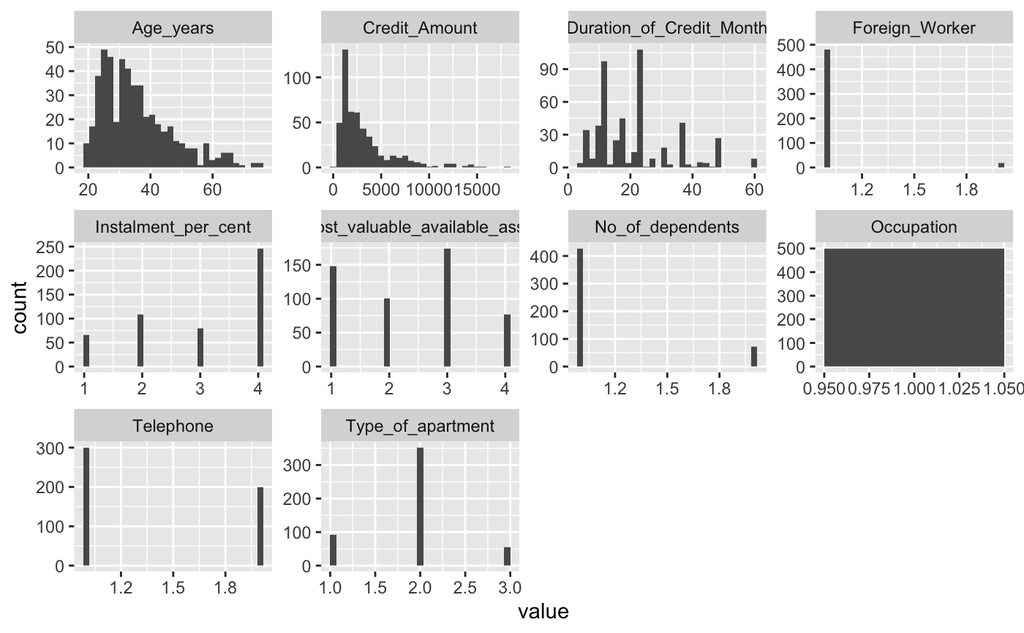

```r
data %>%
  keep(is.numeric) %>%
  gather() %>%
  ggplot(aes(value)) +
    facet_wrap(~ key, scales = "free") +
    geom_histogram()
```

We will remove `Foreign-Worker`, `Occupation` as thet are with low variability in values.

```r
data$Foreign_Worker <- NULL
data$Occupation <- NULL
```

In addition, let’s check for the categorical variables.

```r
table(data$Credit_Application_Result)
```

```
    Creditworthy Non-Creditworthy
             358              142
```

```r
table(data$Account_Balance)
```

```
  No Account Some Balance
         262          238
```

```r
table(data$Payment_Status_of_Previous_Credit)
```

```
No Problems (in this bank)                    Paid Up              Some Problems
                       204                        260                         36
```

```r
table(data$Purpose)
```

```
Home Related      New car        Other     Used car
         355           47           15           83
```

```r
table(data$Value_Savings_Stocks)
```

```
    < £100 £100-£1000       None
        48        154        298
```

```r
table(data$Length_of_current_employment)
```

```
  < 1yr 1-4 yrs 4-7 yrs
    279      97     124
```

```r
table(data$Guarantors)
```

```
None  Yes
 457   43
```

```r
table(data$Concurrent_Credits)
```

```
Other Banks/Depts
              500
```

```r
table(data$No_of_Credits_at_this_Bank)
```

```
          1 More than 1
        320         180
```

It can be found that for the target variable `Credit_Application_Result`, 358 applications are labeled creditworthy and the other 142 are non-creditworthy.

We will remove `Concurrent_credits` as it only has one distinct value.

```r
data$Concurrent_Credits <- NULL
```

Last step is to convert the character variables to factor type.

```r
# change all character columns to factor
data <- as.data.frame(unclass(data))
data$Credit_Application_Result <- factor(data$Credit_Application_Result, levels = c("Non-Creditworthy", "Creditworthy"))

# check the converted data
glimpse(data)
```

```
Rows: 500
Columns: 16
$ Credit_Application_Result         <fct> Creditworthy, Creditworthy, Creditworthy, Cred…
$ Account_Balance                   <fct> Some Balance, Some Balance, Some Balance, Some…
$ Duration_of_Credit_Month          <dbl> 4, 4, 4, 4, 6, 6, 6, 6, 6, 6, 6, 6, 6, 6, 6, 6…
$ Payment_Status_of_Previous_Credit <fct> Paid Up, Paid Up, No Problems (in this bank), …
$ Purpose                           <fct> Other, Home Related, Home Related, Home Relate…
$ Credit_Amount                     <dbl> 1494, 1494, 1544, 3380, 343, 362, 433, 454, 48…
$ Value_Savings_Stocks              <fct> £100-£1000, £100-£1000, None, None, None, < £1…
$ Length_of_current_employment      <fct> < 1yr, < 1yr, 1-4 yrs, 1-4 yrs, < 1yr, < 1yr, …
$ Instalment_per_cent               <dbl> 1, 1, 2, 1, 4, 4, 4, 3, 3, 2, 3, 4, 2, 1, 2, 4…
$ Guarantors                        <fct> None, None, None, None, None, None, None, None…
$ Most_valuable_available_asset     <dbl> 1, 1, 1, 1, 1, 3, 2, 2, 1, 1, 1, 4, 1, 2, 2, 3…
$ Age_years                         <dbl> 33, 29, 42, 37, 27, 52, 24, 22, 28, 23, 39, 36…
$ Type_of_apartment                 <dbl> 2, 2, 2, 2, 2, 2, 1, 2, 2, 1, 2, 3, 2, 2, 2, 2…
$ No_of_Credits_at_this_Bank        <fct> 1, 1, More than 1, 1, 1, More than 1, 1, 1, 1,…
$ No_of_dependents                  <dbl> 2, 2, 2, 2, 1, 1, 2, 1, 1, 1, 1, 1, 1, 1, 1, 2…
$ Telephone                         <dbl> 1, 1, 1, 1, 1, 1, 1, 1, 1, 1, 2, 1, 1, 1, 1, 1…
```

Now 16 variables remaining with only numeric and factor type of values. Data preparation process is finished.

# 3. Model Planning and Building

As the answer of whether a loan applicant is creditworthy is binary (yes or no), so we need to use Binary Classification Model, such as Logistical Regression and Decision Tree, to make the decisions. The Forest Model , usually for Non-Binary Model, are also applicable here.

Primarily, let’s split the data into train and test set.

```r
# Split the data into train and test set
dpart <- createDataPartition(data$Credit_Application_Result, p = 0.75, list = FALSE)
train <- data[dpart, ]
test <- data[-dpart, ]
```

## 3.1 Logistic Regression Model

```r
log_reg <- glm(data = train, Credit_Application_Result ~., family = "binomial")

summary(log_reg)
```

```
Call:
glm(formula = Credit_Application_Result ~ ., family = "binomial",
    data = train)

Deviance Residuals:
    Min       1Q   Median       3Q      Max
-2.6260  -0.7010   0.4580   0.7188   2.1024

Coefficients:
                                                 Estimate Std. Error z value Pr(>|z|)
(Intercept)                                     4.128e+00  1.100e+00   3.753 0.000175 ***
Account_BalanceSome Balance                     1.257e+00  2.980e-01   4.216 2.49e-05 ***
Duration_of_Credit_Month                       -2.664e-02  1.420e-02  -1.876 0.060716 .
Payment_Status_of_Previous_CreditPaid Up       -6.380e-01  3.762e-01  -1.696 0.089899 .
Payment_Status_of_Previous_CreditSome Problems -1.558e+00  5.256e-01  -2.964 0.003035 **
PurposeNew car                                  1.912e+00  8.019e-01   2.385 0.017084 *
PurposeOther                                    7.043e-01  9.092e-01   0.775 0.438563
PurposeUsed car                                -3.923e-02  3.618e-01  -0.108 0.913648
Credit_Amount                                  -5.793e-05  7.152e-05  -0.810 0.417938
Value_Savings_Stocks£100-£1000                 -1.322e-01  5.201e-01  -0.254 0.799416
Value_Savings_StocksNone                       -7.749e-01  4.696e-01  -1.650 0.098921 .
Length_of_current_employment1-4 yrs             8.410e-01  3.708e-01   2.268 0.023329 *
Length_of_current_employment4-7 yrs             5.438e-01  3.807e-01   1.428 0.153171
Instalment_per_cent                            -3.384e-01  1.433e-01  -2.361 0.018205 *
GuarantorsYes                                   1.827e-02  4.371e-01   0.042 0.966653
Most_valuable_available_asset                  -2.610e-01  1.506e-01  -1.733 0.083029 .
Age_years                                      -1.023e-02  1.401e-02  -0.730 0.465091
Type_of_apartment                               2.902e-01  2.830e-01   1.025 0.305160
No_of_Credits_at_this_BankMore than 1          -4.111e-01  3.733e-01  -1.101 0.270795
No_of_dependents                               -5.005e-01  4.035e-01  -1.240 0.214797
Telephone                                      -8.533e-02  3.011e-01  -0.283 0.776888
---
Signif. codes:  0 ‘***’ 0.001 ‘**’ 0.01 ‘*’ 0.05 ‘.’ 0.1 ‘ ’ 1

(Dispersion parameter for binomial family taken to be 1)

    Null deviance: 449.11  on 375  degrees of freedom
Residual deviance: 353.39  on 355  degrees of freedom
AIC: 395.39

Number of Fisher Scoring iterations: 5
```

The character "*" indicates the significant variables in logistic regression model, including `Account_Balance`, `Payment_Status_of_Previous_Credit`, `Purpose`, `Length_of_current_employment` and `Instalment_per_cent`.

```r
pre_log_reg <- predict(log_reg, type = c("response"))
```

```r
predict_result <- ifelse(pre_log_reg > 0.5, "Creditworthy", "Non-Creditworthy")

table(Credit_Application_Result, predict_result)
```

```
                         predict_result
Credit_Application_Result Creditworthy Non-Creditworthy
         Creditworthy              228               41
         Non-Creditworthy           79               28
```

```r
# Calculate the model overall accuracy
(228+28) / (228 + 79 + 41 +28)
```

```
[1] 0.6808511
```

```r
# Calculate the accuracy for Creditworthy
228 / (228 + 41)
```

```
[1] 0.8475836
```

The overall accuracy is 0.68, not very good. But the accuracy for `Creditworthy` is about 0.85, indicating a decent accuracy rate.

Let’s predict for test data!

```r
pre_log_reg_test <- predict(log_reg, newdata = test, type = c("response"))

predict_result_2 <- as.factor(ifelse(pre_log_reg_test > 0.5, "Creditworthy", "Non-Creditworthy"))

predict_result_2 <- factor(predict_result_2, levels = c("Non-Creditworthy", "Creditworthy"))

test$Result_Predict <- predict_result_2

cm_lr <- confusionMatrix(data = predict_result_2, reference = test$Credit_Application_Result)
cm_lr
```

```
Confusion Matrix and Statistics

                  Reference
Prediction         Non-Creditworthy Creditworthy
  Non-Creditworthy               12            9
  Creditworthy                   23           80

               Accuracy : 0.7419
                 95% CI : (0.6557, 0.8163)
    No Information Rate : 0.7177
    P-Value [Acc > NIR] : 0.31294

                  Kappa : 0.2751

 Mcnemar's Test P-Value : 0.02156

            Sensitivity : 0.34286
            Specificity : 0.89888
         Pos Pred Value : 0.57143
         Neg Pred Value : 0.77670
             Prevalence : 0.28226
         Detection Rate : 0.09677
   Detection Prevalence : 0.16935
      Balanced Accuracy : 0.62087

       'Positive' Class : Non-Creditworthy
```

We get an overall accuracy of 0.7419. The accuracy for `Creditworthy` is as high as 0.89888, but the accuracy for `Non-Creditworthy` is only 0.34286. Our model has a bias in predicting `Creditworthy` much better than `Non-creditworthy`.

[figure not shown]

```r
roc_lr <- roc(response = Credit_Application_Result, predictor = Result_Predict, data = test, plot = TRUE, print.auc = TRUE, col = "red")
```

## 3.2 Decision Tree Model

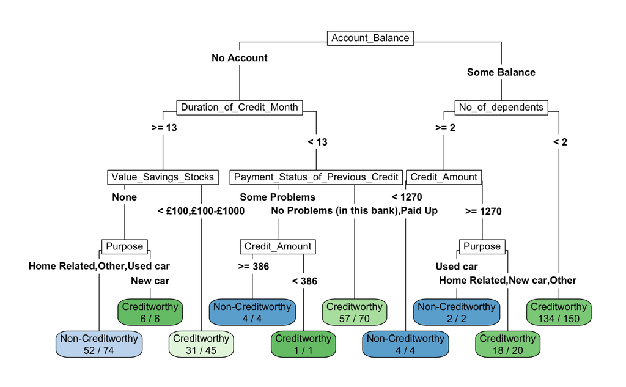

```r
dt <- rpart(Credit_Application_Result ~ .,
            data = train,
            method = "class",
            control = rpart.control(minsplit = 1, maxdepth = 4, cp = 0),
            parms = list(split = "information"))

rpart.plot(dt, type = 5, extra = 2)
```

```r
# fitting decision tree classification model
test$Result_Predict <- NULL
predict_dt <- predict(dt, newdata = test, type = "class")
```

```r
test$Result_Predict <- predict_dt

cm_dt <- confusionMatrix(data = predict_dt, reference = test$Credit_Application_Result)
cm_dt
```

```
Confusion Matrix and Statistics

                  Reference
Prediction         Non-Creditworthy Creditworthy
  Non-Creditworthy               15           12
  Creditworthy                   20           77

               Accuracy : 0.7419
                 95% CI : (0.6557, 0.8163)
    No Information Rate : 0.7177
    P-Value [Acc > NIR] : 0.3129

                  Kappa : 0.3156

 Mcnemar's Test P-Value : 0.2159

            Sensitivity : 0.4286
            Specificity : 0.8652
         Pos Pred Value : 0.5556
         Neg Pred Value : 0.7938
             Prevalence : 0.2823
         Detection Rate : 0.1210
   Detection Prevalence : 0.2177
      Balanced Accuracy : 0.6469

       'Positive' Class : Non-Creditworthy
```

We get an overall accuracy of 0.7419, same with logistic regression model. The accuracy for `Creditworthy` is as high as 0.8652, slightly less than logistic regression model, but the accuracy for `Non-Creditworthy` is with a better value of 0.4286. The decision tree model also has a bias in predicting `Creditworthy` much better than `Non-creditworthy`.

As previous model, we can plot the ROC for decision tree result to check the AUC value, which is 0.647.

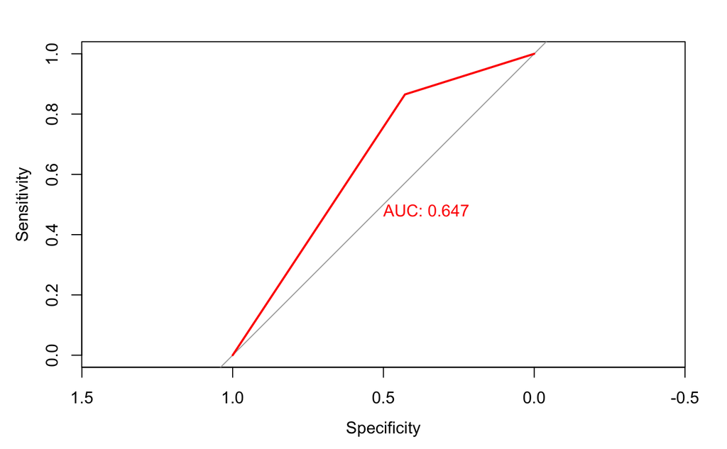

```r
roc_dt <- roc(test$Credit_Application_Result, as.numeric(test$Result_Predict), plot = TRUE, print.auc = TRUE, col = "red")
```

## 3.3 Random Forest Model

```r
rf <- randomForest(Credit_Application_Result ~ ., data = train, importance = TRUE)

test$Result_Predict <- NULL
predict_rf <- predict(rf, newdata = test, type = "class")

test$Result_Predict <- predict_dt

cm_rf <- confusionMatrix(data = predict_rf, reference = test$Credit_Application_Result)
cm_rf
```

```
Confusion Matrix and Statistics

                  Reference
Prediction         Non-Creditworthy Creditworthy
  Non-Creditworthy                9            6
  Creditworthy                   26           83

               Accuracy : 0.7419
                 95% CI : (0.6557, 0.8163)
    No Information Rate : 0.7177
    P-Value [Acc > NIR] : 0.3129356

                  Kappa : 0.2295

 Mcnemar's Test P-Value : 0.0007829

            Sensitivity : 0.25714
            Specificity : 0.93258
         Pos Pred Value : 0.60000
         Neg Pred Value : 0.76147
             Prevalence : 0.28226
         Detection Rate : 0.07258
   Detection Prevalence : 0.12097
      Balanced Accuracy : 0.59486

       'Positive' Class : Non-Creditworthy
```

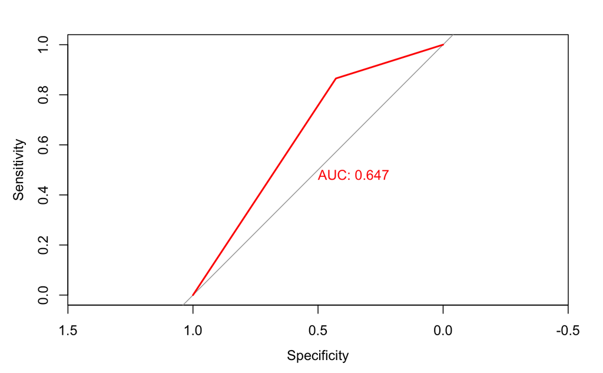

```r
roc_rm <- roc(test$Credit_Application_Result, as.numeric(test$Result_Predict), plot = TRUE, print.auc = TRUE, col = "red")
```

We get an overall accuracy of 0.7419, same with logistic regression model and decision tree. The accuracy for `Creditworthy` is as high as 0.93258, higher than logistic regression model, but the accuracy for `Non-Creditworthy` is with a lowest value of 0.25714. The Random Forest model has the biggest bias in predicting `Creditworthy` better than `Non-creditworthy`.

# 4. Communicate The Results

Considering below criterias: - Overall Accuracy against your Validation set - Accuracy within “Creditworthy” and “Non-Creditworthy” segments - ROC graph - Bias in the Confusion Matrices

# 5. Operationalize

Let’s use the our Logistic Regression Model to predict the loan default risk for the new customers.

```r
class(c("x", "y"))
```

```
[1] "character"
```

```r
col_names <- as.character(names(data))

length(col_names)
```

```
[1] 16
```

```r
#col_names <- col_names[2:16]
col_names
```

```
 [1] "Credit_Application_Result"         "Account_Balance"
 [3] "Duration_of_Credit_Month"          "Payment_Status_of_Previous_Credit"
 [5] "Purpose"                           "Credit_Amount"
 [7] "Value_Savings_Stocks"              "Length_of_current_employment"
 [9] "Instalment_per_cent"               "Guarantors"
[11] "Most_valuable_available_asset"     "Age_years"
[13] "Type_of_apartment"                 "No_of_Credits_at_this_Bank"
[15] "No_of_dependents"                  "Telephone"
```

```r
# Predict for new customer data
predict_new <- predict(log_reg, newdata = new_data[, col_names], type = c("response"))
```

```r
predict_new <- ifelse(predict_new > 0.5, 1, 0)
sum(predict_new)
```

```
[1] 400
```

Total 400 out the 500 new customers are predicted as creditworthy. We can transfer the prediction result with predicted customer label to the manager of the bank as our plan stated at the beginning of this article.